# week-2-homework

**Question 4.1** Describe a situation or problem from your job, everyday life, current events, etc., for which a clustering model would be appropriate. List some (up to 5) predictors that you might use.

Clustering algorithms can be used in recommender systems to analyse user data. These clusters can be used to can be used to group similar users together based on their preferences and behaviors.

For example a recommender system for a streaming platform might implement clustering based on:

1. Genre of a show
2. Length, such as the length of one episode, or number of episodes, or number of seasons
3. Producer, director or production studio of a show
4. The cast of the show

**Question 4.2** The iris data set `iris.txt` contains 150 data points, each with four predictor variables and one categorical response. The predictors are the width and length of the sepal and petal of flowers and the response is the type of flower. The data is available from the R library datasets and can be accessed with iris once the library is loaded. It is also available at the UCI Machine Learning Repository (https://archive.ics.uci.edu/ml/datasets/Iris). *The response values are only given to see how well a specific method performed and should not be used to build the model.* Use the R function `kmeans` to cluster the points as well as possible. Report the best combination of predictors, your suggested value of k, and how well your best clustering predicts flower type.

Ref: https://www.datacamp.com/tutorial/k-means-clustering-r

Ref: https://www.rdocumentation.org/packages/stats/versions/3.6.2/topics/kmeans

Ref: https://www.analyticsvidhya.com/blog/2021/01/in-depth-intuition-of-k-means-clustering-algorithm-in-machine-learning/

Ref: https://www.analyticsvidhya.com/blog/2019/08/comprehensive-guide-k-means-clustering/

Ref: https://vitalflux.com/kmeans-silhouette-score-explained-with-python-example/

For this question, we’re going to use the `kmeans()` function to cluster the Iris dataset.

First, let’s go ahead and load the dataset. The `iris` dataset is a built-in dataset which we can access via the `datasets` package in R, stored as the variable `iris`.

|  | Sepal.Length | Sepal.Width | Petal.Length | Petal.Width | Species |
| --- | --- | --- | --- | --- | --- |
| 1 | 5.1 | 3.5 | 1.4 | 0.2 | setosa |
| 2 | 4.9 | 3.0 | 1.4 | 0.2 | setosa |
| 3 | 4.7 | 3.2 | 1.3 | 0.2 | setosa |
| 4 | 4.6 | 3.1 | 1.5 | 0.2 | setosa |
| 5 | 5.0 | 3.6 | 1.4 | 0.2 | setosa |

Remember that the `iris` dataset comes with a response variable column, which we do not want when training an unsupervised learning clustering model. So let’s go ahead and remove that column from our dataset and store the modified dataset as `iris_unlabelled`.

|  | Sepal.Length | Sepal.Width | Petal.Length | Petal.Width |
| --- | --- | --- | --- | --- |
| 1 | 5.1 | 3.5 | 1.4 | 0.2 |
| 2 | 4.9 | 3.0 | 1.4 | 0.2 |
| 3 | 4.7 | 3.2 | 1.3 | 0.2 |
| 4 | 4.6 | 3.1 | 1.5 | 0.2 |
| 5 | 5.0 | 3.6 | 1.4 | 0.2 |

Now we implement our k-means model. We will loop through 10 values of k and calculate the within-cluster sum of squares (WCSS) for each value of k.

WCSS is the sum of squared distance between each data point and the centroid in the cluster. In the lectures, this is part of the formula that was given to us in lecture 4.3 $\sum_{j}(x_{ij}-z_{jk})^{2}$, and our overall aim is to minimize this value to the point where increasing the value of k no longer significantly affects the WCSS.

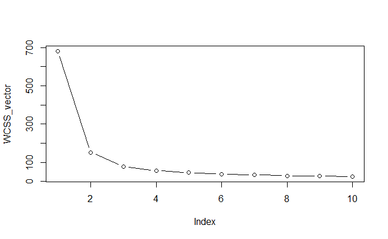

From this graph, we can see that the optimal value of k is probably 2 or 3. The elbow method is not an exact method and there can be cases such as this where the bend in the “elbow” is not obvious, making it difficult to determine the exact optimal value of k.

To be more confident in our choice, we can turn to a second metric to evaluate the performance of our model.

Unlike in classification, accuracy is not going to be a very good metric for evaluating clustering. In practice, we are dealing with unlabelled data and will not know what the “correct” clustering should be. Instead, one of the metrics commonly used in evaluating the quality of a clustering model is the silhouette plot, which we can visualize with the help of the `cluster` and `factoextra` packages.

```r
library(factoextra)
```

A ‘silhouette’ refers to a method of measuring consistency within clusters of data. The silhouette score is a measure of how similar a data point is to its own cluster, compared to other clusters. The silhouette score ranges from -1 to +1, where a high score indicates that the data point is well matched to its own cluster and poorly matched to other clusters.

Since we have already narrowed our optimal values for k down to either k=2 or k=3, let’s plot a silhouette plot for each of these:

|  | cluster | size | ave.sil.width |
| --- | --- | --- | --- |
| 1 | 1 | 53 | 0.91 |
| 2 | 2 | 97 | 0.82 |

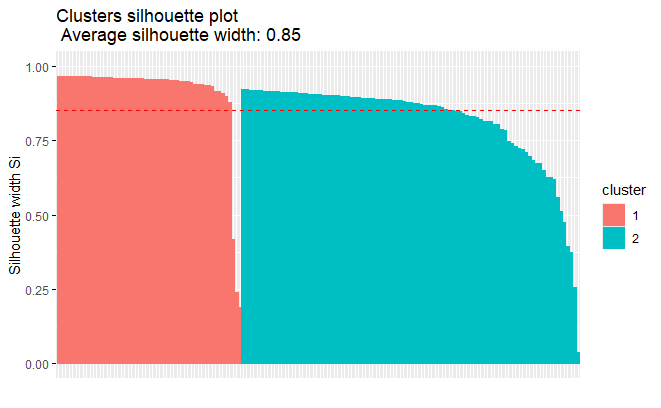

|  | cluster | size | ave.sil.width |
| --- | --- | --- | --- |
| 1 | 1 | 50 | 0.95 |
| 2 | 2 | 62 | 0.61 |
| 3 | 3 | 38 | 0.66 |

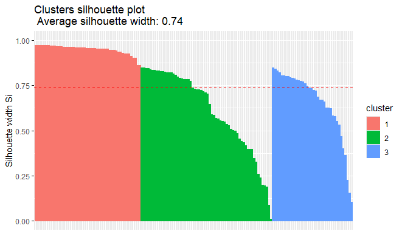

The average silhouette scores for both k=2 and k=3 are very high, as expected. Although the silhouette score for k=2 (0.85) is higher than that of k=3 (0.74), the width of the silhouette plot representing each cluster also is a deciding point. For plot with k=3, the width of each cluster is more uniform than the plot with k=2, which has one cluster much wider than the other. Therefore, we can select the optimal number of clusters as 3.

Let’s re-train the model with our chosen value of k=3 and plot the clusters to see how well our clustering model performs on the `iris` dataset.

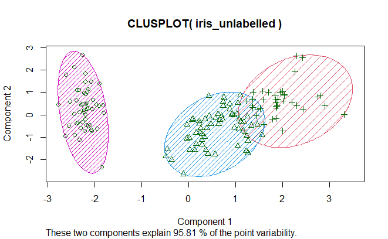

As mentioned before, we do not typically have response variables available for clustering models. However, since the Iris dataset does contain labels, we might as well take advantage of that to observe how our model has separated the data points into clusters.

```r
table(model$cluster, iris$Species)
```

```
    setosa versicolor virginica
  1     50          0         0
  2      0         48        14
  3      0          2        36
```

From this breakdown, we can see the setosa cluster perfectly explained, meanwhile virginica and versicolor have some noise between their clusters.

**Question 5.1** Using crime data from the file `uscrime.txt` (http://www.statsci.org/data/general/uscrime.txt, description at http://www.statsci.org/data/general/uscrime.html), test to see whether there are any outliers in the last column (number of crimes per 100,000 people). Use the `grubbs.test` function in the `outliers` package in R.

Ref: https://www.rdocumentation.org/packages/outliers/versions/0.15/topics/grubbs.test

Ref: https://www.itl.nist.gov/div898/handbook/eda/section3/eda35h1.htm

Ref: https://www.statisticshowto.com/grubbs-test/

For this question, we will be using the Grubbs’ test to detect outliers in the last column of the `uscrime` dataset. the `grubbs.test` function is found in the `outliers` package.

From the NIST Engineering Statistics Handbook:

Grubbs’ test (Grubbs 1969 and Stefansky 1972) is used to detect a single outlier in a univariate data set that follows an approximately normal distribution.

Grubbs’ test is defined for the hypothesis:

- H<sub>0</sub>: There are no outliers in the dataset
- H<sub>1</sub>: There is exactly one outlier in the dataset

Note: All hypothesis tests in this exercise is performed at 95% confidence-level

|  | M | So | Ed | Po1 | Po2 | LF | M.F | Pop | NW | U1 | U2 | Wealth | Ineq | Prob | Time | Crime |
| --- | --- | --- | --- | --- | --- | --- | --- | --- | --- | --- | --- | --- | --- | --- | --- | --- |
| 1 | 15.1 | 1 | 9.1 | 5.8 | 5.6 | 0.510 | 95.0 | 33 | 30.1 | 0.108 | 4.1 | 3940 | 26.1 | 0.084602 | 26.2011 | 791 |
| 2 | 14.3 | 0 | 11.3 | 10.3 | 9.5 | 0.583 | 101.2 | 13 | 10.2 | 0.096 | 3.6 | 5570 | 19.4 | 0.029599 | 25.2999 | 1635 |
| 3 | 14.2 | 1 | 8.9 | 4.5 | 4.4 | 0.533 | 96.9 | 18 | 21.9 | 0.094 | 3.3 | 3180 | 25.0 | 0.083401 | 24.3006 | 578 |
| 4 | 13.6 | 0 | 12.1 | 14.9 | 14.1 | 0.577 | 99.4 | 157 | 8.0 | 0.102 | 3.9 | 6730 | 16.7 | 0.015801 | 29.9012 | 1969 |
| 5 | 14.1 | 0 | 12.1 | 10.9 | 10.1 | 0.591 | 98.5 | 18 | 3.0 | 0.091 | 2.0 | 5780 | 17.4 | 0.041399 | 21.2998 | 1234 |
| 6 | 12.1 | 0 | 11.0 | 11.8 | 11.5 | 0.547 | 96.4 | 25 | 4.4 | 0.084 | 2.9 | 6890 | 12.6 | 0.034201 | 20.9995 | 682 |

```r
# view last column
summary(crime[, 16])
```

```
   Min. 1st Qu.  Median    Mean 3rd Qu.    Max.
  342.0   658.5   831.0   905.1  1057.5  1993.0
```

Since the Grubbs’ test is based on the assumption that the data is normally distributed, we should verify that our data can actually be approximated as a normal distribution before we apply the test.

We can do this through a couple of ways:

1. Histogram plot

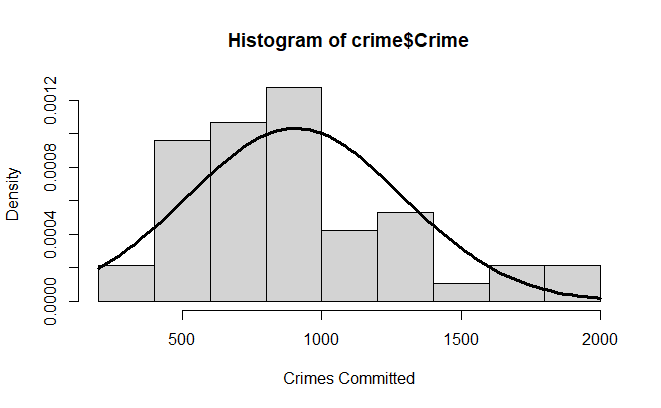

Here we can see that that there is a clear right skew for the data in the `Crime` column. The distribution is not symmetrical and thus cannot be described as being normally distributed.

2. Shapiro-Wilk test

```r
# shapiro-wilk test
shapiro.test(crime$Crime)
```

```
    Shapiro-Wilk normality test

data:  crime$Crime
W = 0.91273, p-value = 0.001882
```

Based on these 2 tests, it’s pretty clear that we are not dealing with a univariate normal distribution.

There is a chance that the data is *mostly* normally distributed and is being seriously affected by an extreme outlier. To check this, we will use the Grubbs’ test to identify one outlier, then run the Shapiro-Wilk test again to check if the distribution is normal. If the data still fails the Shapiro-Wilk test, then the Grubbs’ test is not suited for it.

Use the parameter `type=10` to identify one outlier on one tail of the distribution. By default, this is the *right* tail.

```r
# identify one outlier
grubbs.test(crime[,16], type=10)
```

```
    Grubbs test for one outlier

data:  crime[, 16]
G = 2.81287, U = 0.82426, p-value = 0.07887
alternative hypothesis: highest value 1993 is an outlier
```

The test has identified the data point 1993 as an outlier. This is accompanied by a p-value of 0.07887. Because the p-value is more than 0.05, we fail to reject the null hypothesis that this data point is an outlier; we do not have enough evidence to say that 1993 is an outlier.

Let’s see what happens if we drop 1993 from the data set:

|  | M | So | Ed | Po1 | Po2 | LF | M.F | Pop | NW | U1 | U2 | Wealth | Ineq | Prob | Time | Crime |
| --- | --- | --- | --- | --- | --- | --- | --- | --- | --- | --- | --- | --- | --- | --- | --- | --- |
| 1 | 15.1 | 1 | 9.1 | 5.8 | 5.6 | 0.510 | 95.0 | 33 | 30.1 | 0.108 | 4.1 | 3940 | 26.1 | 0.084602 | 26.2011 | 791 |
| 2 | 14.3 | 0 | 11.3 | 10.3 | 9.5 | 0.583 | 101.2 | 13 | 10.2 | 0.096 | 3.6 | 5570 | 19.4 | 0.029599 | 25.2999 | 1635 |
| 3 | 14.2 | 1 | 8.9 | 4.5 | 4.4 | 0.533 | 96.9 | 18 | 21.9 | 0.094 | 3.3 | 3180 | 25.0 | 0.083401 | 24.3006 | 578 |
| 4 | 13.6 | 0 | 12.1 | 14.9 | 14.1 | 0.577 | 99.4 | 157 | 8.0 | 0.102 | 3.9 | 6730 | 16.7 | 0.015801 | 29.9012 | 1969 |
| 5 | 14.1 | 0 | 12.1 | 10.9 | 10.1 | 0.591 | 98.5 | 18 | 3.0 | 0.091 | 2.0 | 5780 | 17.4 | 0.041399 | 21.2998 | 1234 |
| 6 | 12.1 | 0 | 11.0 | 11.8 | 11.5 | 0.547 | 96.4 | 25 | 4.4 | 0.084 | 2.9 | 6890 | 12.6 | 0.034201 | 20.9995 | 682 |
| 7 | 12.7 | 1 | 11.1 | 8.2 | 7.9 | 0.519 | 98.2 | 4 | 13.9 | 0.097 | 3.8 | 6200 | 16.8 | 0.042100 | 20.6993 | 963 |
| 8 | 13.1 | 1 | 10.9 | 11.5 | 10.9 | 0.542 | 96.9 | 50 | 17.9 | 0.079 | 3.5 | 4720 | 20.6 | 0.040099 | 24.5988 | 1555 |
| 9 | 15.7 | 1 | 9.0 | 6.5 | 6.2 | 0.553 | 95.5 | 39 | 28.6 | 0.081 | 2.8 | 4210 | 23.9 | 0.071697 | 29.4001 | 856 |
| 10 | 14.0 | 0 | 11.8 | 7.1 | 6.8 | 0.632 | 102.9 | 7 | 1.5 | 0.100 | 2.4 | 5260 | 17.4 | 0.044498 | 19.5994 | 705 |

[output cut: 36 more lines]

```r
# shapiro-wilk test
shapiro.test(df2$Crime)
```

```
    Shapiro-Wilk normality test

data:  df2$Crime
W = 0.93207, p-value = 0.01001
```

With a p-value of < 0.05, this dataset is definitely not normally distributed even with one outlier removed. We can say with confidence that the Grubbs’ test will not produce accurate results and under normal circumstances, should not be used on this dataset.

However, for the purpose of this exercise, let’s continue to try the Grubbs’ test to identify one outlier on the *left* tail.

```r
# identify one outlier (left tail)
grubbs.test(crime[,16], type=10, opposite=T)
```

```
    Grubbs test for one outlier

data:  crime[, 16]
G = 1.45589, U = 0.95292, p-value = 1
alternative hypothesis: lowest value 342 is an outlier
```

The test has identified the data point 342 as an outlier. This is accompanied by a p-value of 1. This p-value is even larger than before, and greater than 0.05. Again, we fail to reject the null hypothesis that this data point is an outlier as we do not have enough evidence to say that 342 is an outlier.

The Grubbs’ test for one outlier on either tail is called with the parameter `type=11` which should return both 1993 and 342:

```r
# identify one outlier on each tail (two tails)
grubbs.test(crime[,16], type=11)
```

```
    Grubbs test for two opposite outliers

data:  crime[, 16]
G = 4.26877, U = 0.78103, p-value = 1
alternative hypothesis: 342 and 1993 are outliers
```

Finally, we try `type=20` to identify two outliers on the right tail.

```r
# identify two outliers on one tail (right tail)
grubbs.test(crime[,16], type=20)
```

```
Error in qgrubbs(q, n, type, rev = TRUE) : n must be in range 3-30
```

Unexpectedly, this code chunk has thrown an error (I have commented it out, so it doesn’t error during the knitting of this document). Here is the error message:

`Error in qgrubbs(q, n, type, rev = TRUE) : n must be in range 3-30`

It appears that the `grubbs.test` function for 2 outliers on one tail only works on datasets of length 3-30. As our dataset has 47 rows, we are not able to run this code.

As expected, using `grubbs.test` on a non-uniform distribution, we are unable to accept a single outlier at the min or max of our crime rate data, and we are unable to test for two outliers at the max due to the size of our dataset.

To identify outliers for a non-uniformly distributed dataset, it is instead recommended to use the Tietjen-Moore test, or the generalized extreme studentized deviate test.

**Question 6.1** Describe a situation or problem from your job, everyday life, current events, etc., for which a Change Detection model would be appropriate. Applying the CUSUM technique, how would you choose the critical value and the threshold?

An asset management company can use CUSUM to monitor portfolios under their management.

Subtle changes in a portfolio’s control chart can indicate that a portfolio is at risk, or that a portfolio is benefiting positively from a change in investment strategy.

I think both the critical and threshold value would be affected by the client’s risk appetite, where a higher risk appetite means a higher critical value/threshold.

**Question 6.2.1** Using July through October daily-high-temperature data for Atlanta for 1996 through 2015, use a CUSUM approach to identify when unofficial summer ends (i.e., when the weather starts cooling off) each year. You can get the data that you need from the file `temps.txt` or online, for example at http://www.iweathernet.com/atlanta-weather-records or https://www.wunderground.com/history/airport/KFTY/2015/7/1/CustomHistory.html. You can use R if you’d like, but it’s straightforward enough that an Excel spreadsheet can easily do the job too.

Ref: https://www.rdocumentation.org/packages/qcc/versions/2.6/topics/cusum

Ref: https://rpubs.com/ssufian/658130

We are going to need a control chart for each year.

```r
library(qcc)
```

|  | DAY | X1996 | X1997 | X1998 | X1999 | X2000 | X2001 | X2002 | X2003 | X2004 | X2005 | X2006 | X2007 | X2008 | X2009 | X2010 | X2011 | X2012 | X2013 | X2014 | X2015 |
| --- | --- | --- | --- | --- | --- | --- | --- | --- | --- | --- | --- | --- | --- | --- | --- | --- | --- | --- | --- | --- | --- |
| 1 | 1-Jul | 98 | 86 | 91 | 84 | 89 | 84 | 90 | 73 | 82 | 91 | 93 | 95 | 85 | 95 | 87 | 92 | 105 | 82 | 90 | 85 |
| 2 | 2-Jul | 97 | 90 | 88 | 82 | 91 | 87 | 90 | 81 | 81 | 89 | 93 | 85 | 87 | 90 | 84 | 94 | 93 | 85 | 93 | 87 |
| 3 | 3-Jul | 97 | 93 | 91 | 87 | 93 | 87 | 87 | 87 | 86 | 86 | 93 | 82 | 91 | 89 | 83 | 95 | 99 | 76 | 87 | 79 |
| 4 | 4-Jul | 90 | 91 | 91 | 88 | 95 | 84 | 89 | 86 | 88 | 86 | 91 | 86 | 90 | 91 | 85 | 92 | 98 | 77 | 84 | 85 |
| 5 | 5-Jul | 89 | 84 | 91 | 90 | 96 | 86 | 93 | 80 | 90 | 89 | 90 | 88 | 88 | 80 | 88 | 90 | 100 | 83 | 86 | 84 |

```r
# rename headers
temps <- temps %>% rename_at(vars(starts_with("X")),funs(str_replace(.,"X","")))

# wide to long
temps2 <- melt(temps, id.vars = c("DAY"),variable.name = "YEAR",value.name="TEMP")
```

```r
# yearly average temperature
mean_yearly<-aggregate(TEMP~YEAR, data=temps2, mean)
head(temp.mean,5)
```

[output not shown]

```r
# yearly standard deviation
sd_yearly<-aggregate(TEMP~YEAR, data=temps2, sd)
head(sd_yearly,5)
```

[output not shown]

```r
# std dev of entire data
sd_overall<-sd(as.matrix(temps[,2:21]), na.rm = TRUE)
sd_overall
```

[output not shown]

```r
# surely we dont need to plot everything out?

temps3<-select(temps,2:21)
CUSUMmodels <- vector(mode="list", length=ncol(df3))
CUSUMviolations <- vector(mode="list", length=ncol(df3))

DI = 4 # flagged at 4 std dev
Shift = 3 # C=(delta*sigma)/2, where delta*sigma = Shift

# loop over years
for (i in 1:ncol(temp3)) {
  CUSUMmodels[[i]] <- cusum(df3[,i],
                            center=mean_yearly$TEMP[i],
                            std.dev=sd_yearly$TEMP[i],
                            decision.interval=DI,
                            se.shift=Shift,
                            plot=F)

  # store any violations in vector
  CUSUMviolations[[i]] <- CUSUMmodels[[i]]$violations$lower
}
```

```r
#looking for minimum expense values and when it occurs
no.violations<-13 # get length(CUSUMviolations)
CUSUMlowest <- vector(mode="list", length=no.violations)
#Years (by groups) with violations. For ex: 2=1997, 3=year 1998 etc. from above loop
x<- c(2,3,5,6,7,9,10,11,12,13,14,17,18)
for (i in x){
  CUSUMlowest[i] <- min(CUSUMviolations[[i]])
}
unlist(CUSUMlowest)#index or when the lowest expenses occurred; the higher means the closer to Oct
```

[output not shown]

```r
#Finding out what the index of low expenses are in terms of actual days of the month
lowtemp.c<-c(120,116,102,120,117,108,121,119,110,122)
df.reconnect<- temps %>% mutate(Low.expense.Index = row_number()) %>% select("DAY","Low.expense.Index")
df.lowtemp.days<- slice(df.reconnect, lowtemp.c)
#Days when expense dollars were lowest
df.lowtemp.days
```

[output not shown]

**Question 6.2.2** Use a CUSUM approach to make a judgment of whether Atlanta’s summer climate has gotten warmer in that time (and if so, when).